# Project: Investigating how the genre impacts a movie

- Introduction
- Data Wrangling
- Exploratory Data Analysis
- Conclusions

## Introduction

In order to investigate how genre impacts a movie, I have downloaded the TMDb movie data cleaned by Kaggle. Each row in this dataset has information regarding a single movie. Primary fields related to our analysis in this row are:

- Title
- Genres
- Release Date
- Budget
- Revenue

In this report, I explore the following:

- How has the popularity of genres changed over the years. This kind of a reflection on the chaning moods of the movie viewing public
- Since this dataset has the adjusted budget and revenue details, I want to explore which genre of movies has the highest/lowest share in the top 100 grossing movies of all time

```python
#Import functions

import pandas as pd
import matplotlib.pyplot as plt
% matplotlib inline
pd.options.mode.chained_assignment = None
```

## Data Wrangling

### General Properties

```python
# Load the data and check the properties of the dataframe
df = pd.read_csv("tmdb-movies.csv")
df.info()
```

```
<class 'pandas.core.frame.DataFrame'>
RangeIndex: 10866 entries, 0 to 10865
Data columns (total 21 columns):
id                      10866 non-null int64
imdb_id                 10856 non-null object
popularity              10866 non-null float64
budget                  10866 non-null int64
revenue                 10866 non-null int64
original_title          10866 non-null object
cast                    10790 non-null object
homepage                2936 non-null object
director                10822 non-null object
tagline                 8042 non-null object
keywords                9373 non-null object
overview                10862 non-null object
runtime                 10866 non-null int64
genres                  10843 non-null object
production_companies    9836 non-null object
release_date            10866 non-null object
vote_count              10866 non-null int64
vote_average            10866 non-null float64
release_year            10866 non-null int64
budget_adj              10866 non-null float64
revenue_adj             10866 non-null float64
dtypes: float64(4), int64(6), object(11)
memory usage: 1.7+ MB
```

```python
# check the first couple of rows in the datset
df.head()
```

|  | id | imdb_id | popularity | budget | revenue | original_title | cast | homepage | director | tagline | ... | overview | runtime | genres | production_companies | release_date | vote_count | vote_average | release_year | budget_adj | revenue_adj |
| --- | --- | --- | --- | --- | --- | --- | --- | --- | --- | --- | --- | --- | --- | --- | --- | --- | --- | --- | --- | --- | --- |
| 0 | 135397 | tt0369610 | 32.985763 | 150000000 | 1513528810 | Jurassic World | Chris Pratt\|Bryce Dallas Howard\|Irrfan Khan\|Vi... | http://www.jurassicworld.com/ | Colin Trevorrow | The park is open. | ... | Twenty-two years after the events of Jurassic ... | 124 | Action\|Adventure\|Science Fiction\|Thriller | Universal Studios\|Amblin Entertainment\|Legenda... | 6/9/15 | 5562 | 6.5 | 2015 | 1.379999e+08 | 1.392446e+09 |
| 1 | 76341 | tt1392190 | 28.419936 | 150000000 | 378436354 | Mad Max: Fury Road | Tom Hardy\|Charlize Theron\|Hugh Keays-Byrne\|Nic... | http://www.madmaxmovie.com/ | George Miller | What a Lovely Day. | ... | An apocalyptic story set in the furthest reach... | 120 | Action\|Adventure\|Science Fiction\|Thriller | Village Roadshow Pictures\|Kennedy Miller Produ... | 5/13/15 | 6185 | 7.1 | 2015 | 1.379999e+08 | 3.481613e+08 |
| 2 | 262500 | tt2908446 | 13.112507 | 110000000 | 295238201 | Insurgent | Shailene Woodley\|Theo James\|Kate Winslet\|Ansel... | http://www.thedivergentseries.movie/#insurgent | Robert Schwentke | One Choice Can Destroy You | ... | Beatrice Prior must confront her inner demons ... | 119 | Adventure\|Science Fiction\|Thriller | Summit Entertainment\|Mandeville Films\|Red Wago... | 3/18/15 | 2480 | 6.3 | 2015 | 1.012000e+08 | 2.716190e+08 |
| 3 | 140607 | tt2488496 | 11.173104 | 200000000 | 2068178225 | Star Wars: The Force Awakens | Harrison Ford\|Mark Hamill\|Carrie Fisher\|Adam D... | http://www.starwars.com/films/star-wars-episod... | J.J. Abrams | Every generation has a story. | ... | Thirty years after defeating the Galactic Empi... | 136 | Action\|Adventure\|Science Fiction\|Fantasy | Lucasfilm\|Truenorth Productions\|Bad Robot | 12/15/15 | 5292 | 7.5 | 2015 | 1.839999e+08 | 1.902723e+09 |
| 4 | 168259 | tt2820852 | 9.335014 | 190000000 | 1506249360 | Furious 7 | Vin Diesel\|Paul Walker\|Jason Statham\|Michelle ... | http://www.furious7.com/ | James Wan | Vengeance Hits Home | ... | Deckard Shaw seeks revenge against Dominic Tor... | 137 | Action\|Crime\|Thriller | Universal Pictures\|Original Film\|Media Rights ... | 4/1/15 | 2947 | 7.3 | 2015 | 1.747999e+08 | 1.385749e+09 |

5 rows × 21 columns

```python
# Check for any duplicate records in the dataset
df.duplicated().sum()
```

```
1
```

```python
# Get rid of the duplicate record
df.drop_duplicates(inplace=True)
df.info()
```

```
<class 'pandas.core.frame.DataFrame'>
Int64Index: 10865 entries, 0 to 10865
Data columns (total 21 columns):
id                      10865 non-null int64
imdb_id                 10855 non-null object
popularity              10865 non-null float64
budget                  10865 non-null int64
revenue                 10865 non-null int64
original_title          10865 non-null object
cast                    10789 non-null object
homepage                2936 non-null object
director                10821 non-null object
tagline                 8041 non-null object
keywords                9372 non-null object
overview                10861 non-null object
runtime                 10865 non-null int64
genres                  10842 non-null object
production_companies    9835 non-null object
release_date            10865 non-null object
vote_count              10865 non-null int64
vote_average            10865 non-null float64
release_year            10865 non-null int64
budget_adj              10865 non-null float64
revenue_adj             10865 non-null float64
dtypes: float64(4), int64(6), object(11)
memory usage: 1.8+ MB
```

```python
# The Genre column shows some null values. Lets drop those rows since we are exploring Genres primarily
df.dropna(subset=['genres'], inplace=True)
df = df.reset_index(drop=True)
df.info()
```

```
<class 'pandas.core.frame.DataFrame'>
RangeIndex: 10842 entries, 0 to 10841
Data columns (total 21 columns):
id                      10842 non-null int64
imdb_id                 10834 non-null object
popularity              10842 non-null float64
budget                  10842 non-null int64
revenue                 10842 non-null int64
original_title          10842 non-null object
cast                    10767 non-null object
homepage                2931 non-null object
director                10800 non-null object
tagline                 8036 non-null object
keywords                9367 non-null object
overview                10839 non-null object
runtime                 10842 non-null int64
genres                  10842 non-null object
production_companies    9826 non-null object
release_date            10842 non-null object
vote_count              10842 non-null int64
vote_average            10842 non-null float64
release_year            10842 non-null int64
budget_adj              10842 non-null float64
revenue_adj             10842 non-null float64
dtypes: float64(4), int64(6), object(11)
memory usage: 1.7+ MB
```

```python
# A lot of columns are pipe delimited values, lets create a function to split the data to get the values as a list
# Input to the function is a dataframe column and the split character
def parse_pipedata(c, s):
    split_list = c.str.split(s)
    ret_list = list()
    for row_index, row in enumerate(split_list):
        for col_index, item in enumerate(row):
            ret_list.append(item)

    #Remove duplicates
    ret_list = list(set(ret_list))
    ret_list.sort()

    #Return the list
    return ret_list
```

## Exploratory Data Analysis

### Find the Genre which is trending highest and lowest in terms of popularity over the years

#### We want to create a dataframe which has the release year and the genre of movie and the average popularity of all movies belonging to that genre for that year. In order to compute a trend, this needs to be a rolling average for 5 years

```python
# Lets get the unique list of Movie Genres
movie_genres = parse_pipedata(df['genres'], '|')
```

```python
# Create a dataframe with only the unique release year as a column
df_genre_popularity = pd.DataFrame({'release_year':df['release_year'].unique()})
df_genre_popularity.info()
```

```
<class 'pandas.core.frame.DataFrame'>
RangeIndex: 56 entries, 0 to 55
Data columns (total 1 columns):
release_year    56 non-null int64
dtypes: int64(1)
memory usage: 528.0 bytes
```

```python
# For each genre
for g in movie_genres:
    #Filter all records for that Genre of Movie
    g_df = df[df['genres'].str.contains(g)==True]

    #Group By Year and find the Average Popularity of the Genre by Year
    mean_pop_df = g_df.groupby(['release_year'], as_index=False)['popularity'].mean().rename(columns={'popularity':g+'_Avg'})

    #Calculate the rolling average popularity of the Genre by Year
    mean_pop_df[g+'_rolling_avg'] = mean_pop_df[g+'_Avg'].rolling(5).mean()

    #Drop the column which is just the Average Popularity
    mean_pop_df = mean_pop_df.drop(g+'_Avg', 1)

    #Merge columns for each iteration to the dataframe created for Genres
    df_genre_popularity = pd.merge(df_genre_popularity, mean_pop_df, on='release_year', how='left')

#Sort and replace NaN with 0's
df_genre_popularity.sort_values('release_year', inplace=True)

# For the ones that didnt have any movies in that year, this will turn up with NaN, so lets replace that by 0
df_genre_popularity.fillna(0, inplace=True)

df_genre_popularity.head()
```

|  | release_year | Action_rolling_avg | Adventure_rolling_avg | Animation_rolling_avg | Comedy_rolling_avg | Crime_rolling_avg | Documentary_rolling_avg | Drama_rolling_avg | Family_rolling_avg | Fantasy_rolling_avg | ... | History_rolling_avg | Horror_rolling_avg | Music_rolling_avg | Mystery_rolling_avg | Romance_rolling_avg | Science Fiction_rolling_avg | TV Movie_rolling_avg | Thriller_rolling_avg | War_rolling_avg | Western_rolling_avg |
| --- | --- | --- | --- | --- | --- | --- | --- | --- | --- | --- | --- | --- | --- | --- | --- | --- | --- | --- | --- | --- | --- |
| 44 | 1960 | 0.00000 | 0.000000 | 0.0 | 0.000000 | 0.000000 | 0.0 | 0.000000 | 0.000000 | 0.000000 | ... | 0.000000 | 0.000000 | 0.0 | 0.0 | 0.000000 | 0.000000 | 0.0 | 0.0 | 0.000000 | 0.000000 |
| 43 | 1961 | 0.00000 | 0.000000 | 0.0 | 0.000000 | 0.000000 | 0.0 | 0.000000 | 0.000000 | 0.000000 | ... | 0.000000 | 0.000000 | 0.0 | 0.0 | 0.000000 | 0.000000 | 0.0 | 0.0 | 0.000000 | 0.000000 |
| 39 | 1962 | 0.00000 | 0.000000 | 0.0 | 0.000000 | 0.000000 | 0.0 | 0.000000 | 0.000000 | 0.000000 | ... | 0.000000 | 0.000000 | 0.0 | 0.0 | 0.000000 | 0.000000 | 0.0 | 0.0 | 0.000000 | 0.000000 |
| 48 | 1963 | 0.00000 | 0.000000 | 0.0 | 0.000000 | 0.000000 | 0.0 | 0.000000 | 0.000000 | 0.000000 | ... | 0.000000 | 0.000000 | 0.0 | 0.0 | 0.000000 | 0.000000 | 0.0 | 0.0 | 0.000000 | 0.000000 |
| 40 | 1964 | 0.68608 | 0.775147 | 0.0 | 0.456946 | 0.487974 | 0.0 | 0.415561 | 0.617636 | 0.326345 | ... | 0.428976 | 0.318389 | 0.0 | 0.0 | 0.390809 | 0.295138 | 0.0 | 0.0 | 0.571699 | 0.313319 |

5 rows × 21 columns

```
Text(0,0.5,'Popularity of the Genre')
```

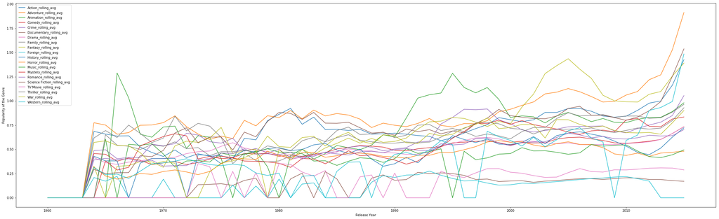

```python
# Now lets create a graph to see which genre of movie has been trending the highest and which one the lowest
ax = df_genre_popularity.plot(x='release_year', figsize=(40,12))
ax.set_xlabel("Release Year")
ax.set_ylabel("Popularity of the Genre")
```

### Research Question 2 Lets look at the top 100 grossing movies ever made and see how genres are distributed across

```python
# Add a column for the net profit for each movie
df['profit_adj'] = df['revenue_adj'] - df['budget_adj']
df.head()
```

|  | id | imdb_id | popularity | budget | revenue | original_title | cast | homepage | director | tagline | ... | runtime | genres | production_companies | release_date | vote_count | vote_average | release_year | budget_adj | revenue_adj | profit_adj |
| --- | --- | --- | --- | --- | --- | --- | --- | --- | --- | --- | --- | --- | --- | --- | --- | --- | --- | --- | --- | --- | --- |
| 0 | 135397 | tt0369610 | 32.985763 | 150000000 | 1513528810 | Jurassic World | Chris Pratt\|Bryce Dallas Howard\|Irrfan Khan\|Vi... | http://www.jurassicworld.com/ | Colin Trevorrow | The park is open. | ... | 124 | Action\|Adventure\|Science Fiction\|Thriller | Universal Studios\|Amblin Entertainment\|Legenda... | 6/9/15 | 5562 | 6.5 | 2015 | 1.379999e+08 | 1.392446e+09 | 1.254446e+09 |
| 1 | 76341 | tt1392190 | 28.419936 | 150000000 | 378436354 | Mad Max: Fury Road | Tom Hardy\|Charlize Theron\|Hugh Keays-Byrne\|Nic... | http://www.madmaxmovie.com/ | George Miller | What a Lovely Day. | ... | 120 | Action\|Adventure\|Science Fiction\|Thriller | Village Roadshow Pictures\|Kennedy Miller Produ... | 5/13/15 | 6185 | 7.1 | 2015 | 1.379999e+08 | 3.481613e+08 | 2.101614e+08 |
| 2 | 262500 | tt2908446 | 13.112507 | 110000000 | 295238201 | Insurgent | Shailene Woodley\|Theo James\|Kate Winslet\|Ansel... | http://www.thedivergentseries.movie/#insurgent | Robert Schwentke | One Choice Can Destroy You | ... | 119 | Adventure\|Science Fiction\|Thriller | Summit Entertainment\|Mandeville Films\|Red Wago... | 3/18/15 | 2480 | 6.3 | 2015 | 1.012000e+08 | 2.716190e+08 | 1.704191e+08 |
| 3 | 140607 | tt2488496 | 11.173104 | 200000000 | 2068178225 | Star Wars: The Force Awakens | Harrison Ford\|Mark Hamill\|Carrie Fisher\|Adam D... | http://www.starwars.com/films/star-wars-episod... | J.J. Abrams | Every generation has a story. | ... | 136 | Action\|Adventure\|Science Fiction\|Fantasy | Lucasfilm\|Truenorth Productions\|Bad Robot | 12/15/15 | 5292 | 7.5 | 2015 | 1.839999e+08 | 1.902723e+09 | 1.718723e+09 |
| 4 | 168259 | tt2820852 | 9.335014 | 190000000 | 1506249360 | Furious 7 | Vin Diesel\|Paul Walker\|Jason Statham\|Michelle ... | http://www.furious7.com/ | James Wan | Vengeance Hits Home | ... | 137 | Action\|Crime\|Thriller | Universal Pictures\|Original Film\|Media Rights ... | 4/1/15 | 2947 | 7.3 | 2015 | 1.747999e+08 | 1.385749e+09 | 1.210949e+09 |

5 rows × 22 columns

```python
# Get the top 100 profitable movies of all time
df_top_100 = df.sort_values('profit_adj', ascending=False).head(100)

# Create an empty dataframe with the Genre list and count list
df_genre_profitability = pd.DataFrame({'genre': movie_genres})
df_genre_profitability['count'] = 0
df_genre_profitability.head()
```

|  | genre | count |
| --- | --- | --- |
| 0 | Action | 0 |
| 1 | Adventure | 0 |
| 2 | Animation | 0 |
| 3 | Comedy | 0 |
| 4 | Crime | 0 |

```python
# For each genre, loop through the list of the top 100 grossing movies to find the count
for i, r in df_genre_profitability.iterrows():
    rcount = 0
    for index, row in df_top_100.iterrows():
        if(row['genres'].find(r['genre'])>=0):
            rcount += 1
    df_genre_profitability['count'][i] = rcount

df_genre_profitability.head()
```

|  | genre | count |
| --- | --- | --- |
| 0 | Action | 45 |
| 1 | Adventure | 67 |
| 2 | Animation | 15 |
| 3 | Comedy | 22 |
| 4 | Crime | 7 |

```
Text(0.5,1,'Top 100 Grossing movies by Genre')
```

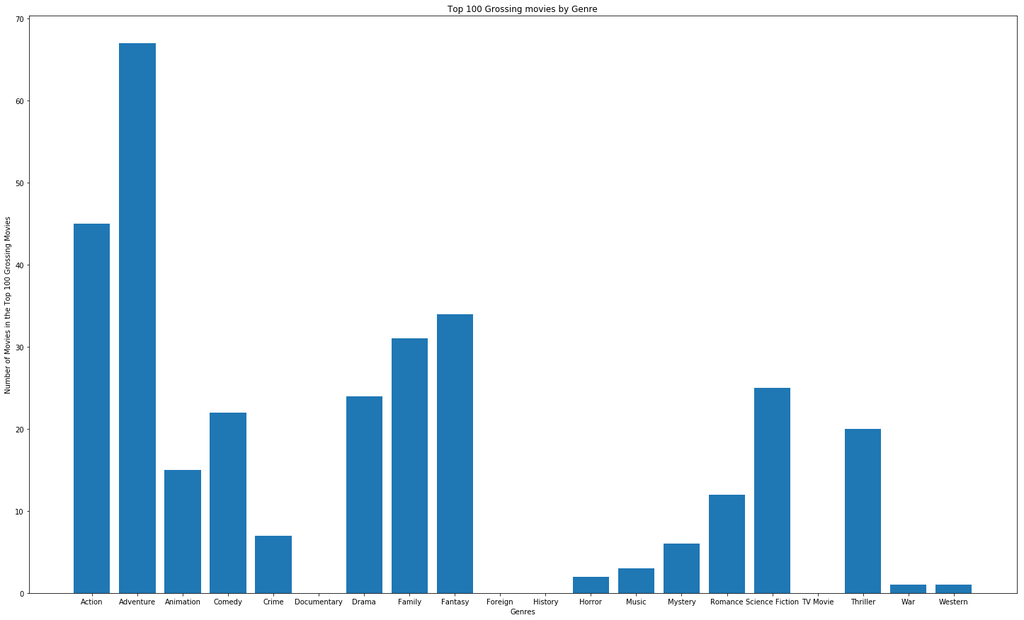

```python
# Create a bar graph to show which genre has the highest numbers in the top 100 grossing movies
plt.figure(figsize=(25,15))
plt.bar(df_genre_profitability['genre'], df_genre_profitability['count'])
plt.xlabel('Genres')
plt.ylabel('Number of Movies in the Top 100 Grossing Movies')
plt.title('Top 100 Grossing movies by Genre')
```

## Conclusions

The Adventure Genre is right now the trending the highest in terms of popularity. Westerns seem to have really fallen out of favor.

Even from the top 100 grossing movies of all time, its evident that the maximum number of them are of genre Adventure.

So Pro Tip for a new film-maker, make it an Adenture movie.